# IODS course project

## Linear discriminant analysis

The analysis will be done using crime rate as a target variable (crime ~) and others as predictors. The analysis results and the dataplot:

```r
lda.fit <- lda(crime ~ ., data = train)
lda.fit
```

```
## Call:
## lda(crime ~ ., data = train)
##
## Prior probabilities of groups:
##       low   med_low  med_high      high
## 0.2376238 0.2623762 0.2475248 0.2524752
##
## Group means:
##                  zn      indus        chas        nox          rm
## low       0.9926910 -0.9210240 -0.10828322 -0.8841782  0.56328239
## med_low  -0.1262228 -0.3179034 -0.01233188 -0.5806201 -0.09925485
## med_high -0.3740445  0.1645282  0.16075196  0.3957185  0.07535485
## high     -0.4872402  1.0171096 -0.04073494  1.0531816 -0.46477083
##                 age        dis        rad        tax    ptratio
## low      -0.8772152  0.8448615 -0.6911655 -0.7550122 -0.4663860
## med_low  -0.3739015  0.3464142 -0.5484874 -0.5122962 -0.1071383
## med_high  0.4037143 -0.3581185 -0.4156770 -0.3004511 -0.2695373
## high      0.8104880 -0.8461155  1.6382099  1.5141140  0.7808718
##                black       lstat        medv
## low       0.38731676 -0.81890555  0.64065750
## med_low   0.31703954 -0.16182614  0.03028284
## med_high  0.07819792  0.05933806  0.15789684
## high     -0.67826348  0.83102319 -0.66021021
##
## Coefficients of linear discriminants:
##                 LD1         LD2        LD3
## zn       0.05265226  0.85547161 -0.9324942
## indus    0.00496019 -0.24104990  0.2793796
## chas    -0.08340098 -0.01510740  0.1473752
## nox      0.42317843 -0.70554387 -1.4487085
## rm      -0.10845655 -0.05651101 -0.1590017
## age      0.22882600 -0.24398274 -0.2179416
## dis     -0.04330019 -0.34119096  0.0510651
## rad      3.09369964  1.04546851  0.2470891
## tax      0.09797703 -0.14024864  0.3375764
## ptratio  0.12470351  0.01819330 -0.4196233
## black   -0.13719567  0.04148966  0.1293439
## lstat    0.21360025 -0.31801704  0.2610109
## medv     0.21559832 -0.42720677 -0.3550551
##
## Proportion of trace:
##    LD1    LD2    LD3
## 0.9465 0.0387 0.0149
```

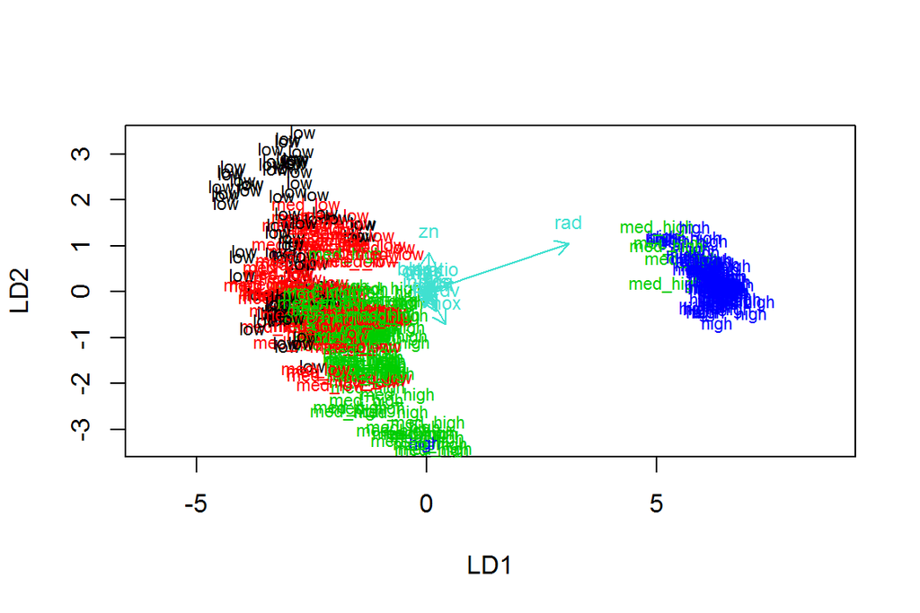

```r
lda.arrows <- function(x, myscale = 1, arrow_heads = 0.1, color = "turquoise", tex = 0.75, choices = c(1,2)){
  heads <- coef(x)
  arrows(x0 = 0, y0 = 0,
         x1 = myscale * heads[,choices[1]],
         y1 = myscale * heads[,choices[2]], col=color, length = arrow_heads)
  text(myscale * heads[,choices], labels = row.names(heads),
       cex = tex, col=color, pos=3)
}
classes <- as.numeric(train$crime)
plot(lda.fit, dimen = 2, col = classes, pch = classes)
lda.arrows(lda.fit, myscale = 1)
```

**The crime variable will be saved to new set “correct_classes” and the variable will be removed from the test set:**

```r
correct_classes <- test$crime
test <- dplyr::select(test, -crime)
```

**LDA model will be used for the test data and the results will be compared with the “correct_classes”.**

```r
lda.pred <- predict(lda.fit, newdata = test)
table(correct = correct_classes, predicted = lda.pred$class)
```

```
##           predicted
## correct    low med_low med_high high
##   low       15      16        0    0
##   med_low    3      10        7    0
##   med_high   1       6       18    1
##   high       0       0        0   25
```

The analysis was able to predict the high crime rate almost perfectly.Biggest difference between correct and predicted crime rate is in low crime rate.

## Clustering

First the Boston data is standardized with scaling and then the distances between observations are measured:

```r
library(MASS)
data('Boston')
boston_sca <- scale(Boston)
dist_eu <- dist(boston_sca)
summary(dist_eu)
```

```
##    Min. 1st Qu.  Median    Mean 3rd Qu.    Max.
##  0.1343  3.4625  4.8241  4.9111  6.1863 14.3970
```

**K-means clustering**

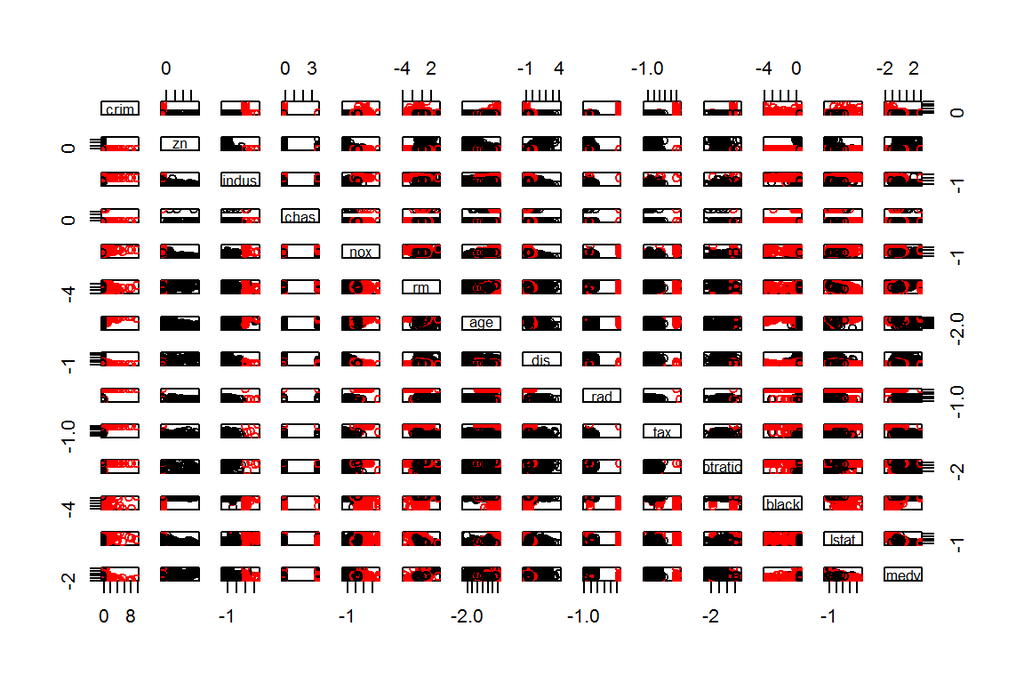

```r
km <-kmeans(boston_sca, centers = 2)
pairs(boston_sca, col = km$cluster)
```

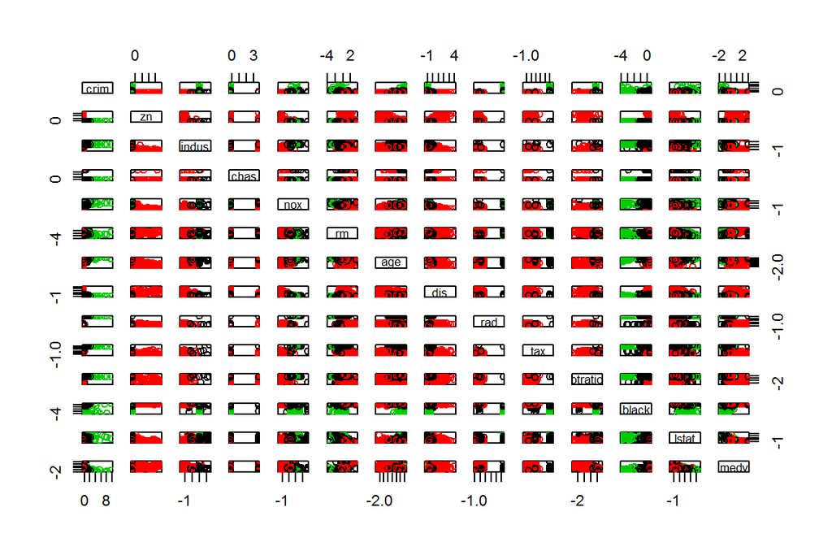

```r
km <-kmeans(boston_sca, centers = 3)
pairs(boston_sca, col = km$cluster)
```

**In my eye three clusters are better but lets run WCSS on the data and try again:**

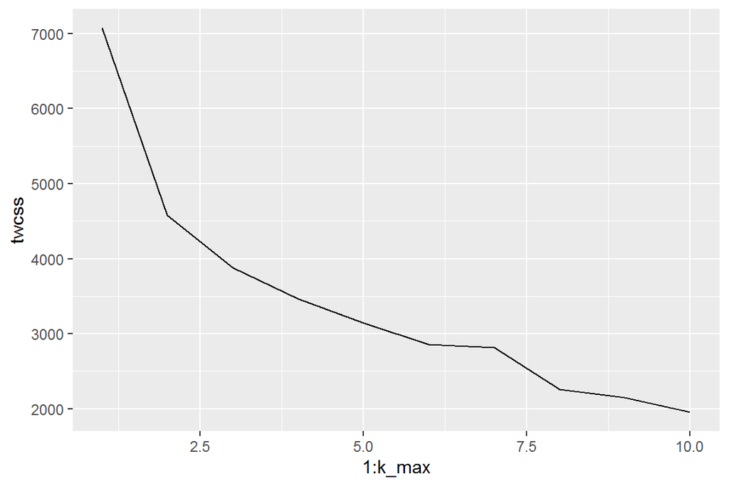

```r
library(ggplot2)
set.seed(123)
k_max <- 10
twcss <- sapply(1:k_max, function(k){kmeans(boston_sca, k)$tot.withinss})
qplot(x = 1:k_max, y = twcss, geom = 'line')
```

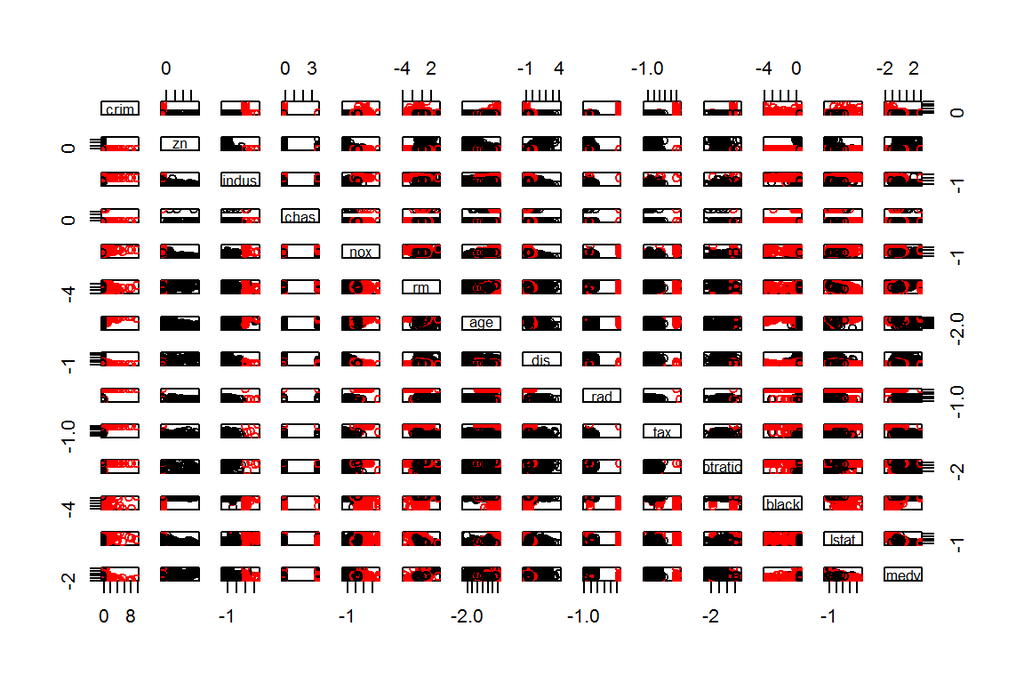

```r
km <-kmeans(boston_sca, centers = 2)
pairs(boston_sca, col = km$cluster)
```

# Chapter 5

**Overview of the data**

```r
human <- read.csv("http://s3.amazonaws.com/assets.datacamp.com/production/course_2218/datasets/human2.txt")

str(human)
```

```
## 'data.frame':    155 obs. of  8 variables:
##  $ Edu2.FM  : num  1.007 0.997 0.983 0.989 0.969 ...
##  $ Labo.FM  : num  0.891 0.819 0.825 0.884 0.829 ...
##  $ Edu.Exp  : num  17.5 20.2 15.8 18.7 17.9 16.5 18.6 16.5 15.9 19.2 ...
##  $ Life.Exp : num  81.6 82.4 83 80.2 81.6 80.9 80.9 79.1 82 81.8 ...
##  $ GNI      : int  64992 42261 56431 44025 45435 43919 39568 52947 42155 32689 ...
##  $ Mat.Mor  : int  4 6 6 5 6 7 9 28 11 8 ...
##  $ Ado.Birth: num  7.8 12.1 1.9 5.1 6.2 3.8 8.2 31 14.5 25.3 ...
##  $ Parli.F  : num  39.6 30.5 28.5 38 36.9 36.9 19.9 19.4 28.2 31.4 ...
```

```r
dim(human)
```

```
## [1] 155   8
```

This data has 155 observations of eight different variables. The data describes Human Development Index, which consists of three dimentions: Long healty life, Knowledge, A decent standard of living. For further information see:[HDI](http://hdr.undp.org/sites/default/files/hdr2018_technical_notes.pdf)

**Graphical overview**

```r
library(GGally)
```

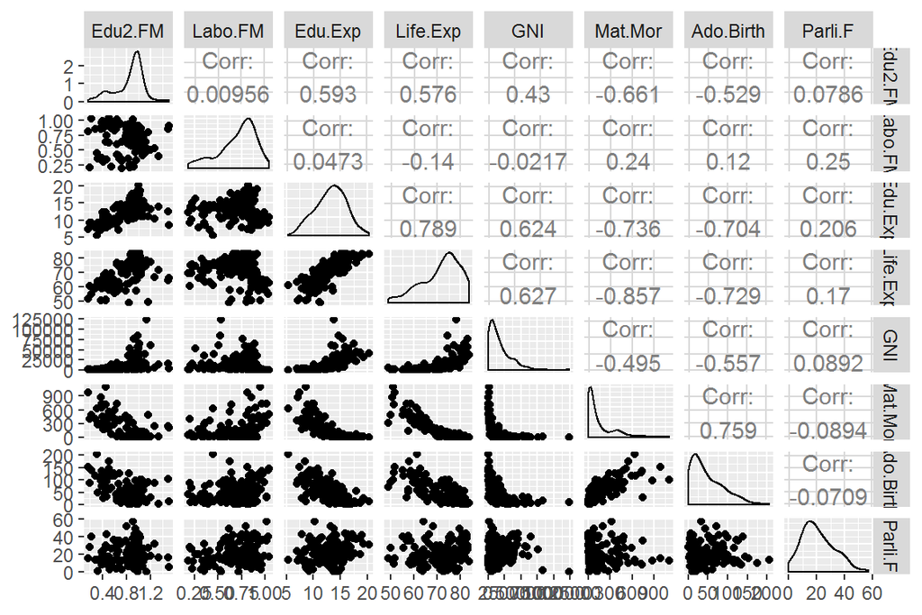

```r
library(corrplot)
library(dplyr)

plot <- ggpairs(human)
plot
```

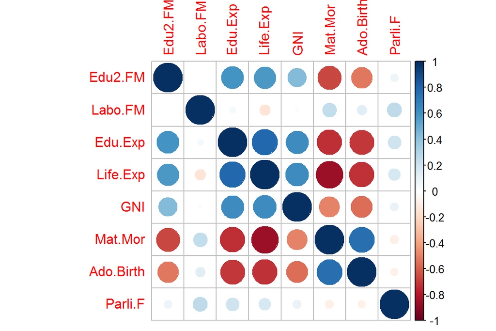

```r
cor(human) %>% corrplot
```

For example the life expectancy at birth correlates negatively to maternal mortality ratio and adolescent birth rate.

## PCA analysis

Principal component analysis (PCA) is dimensionality reduction technique for continuous and correlated variables.It calculates variance in the raw data by making principal components. PCA is affected by the relative scaling and it assumes the larger variance is more important than smaller variance.

PCA analysis will be done next both in raw data and scaled data:

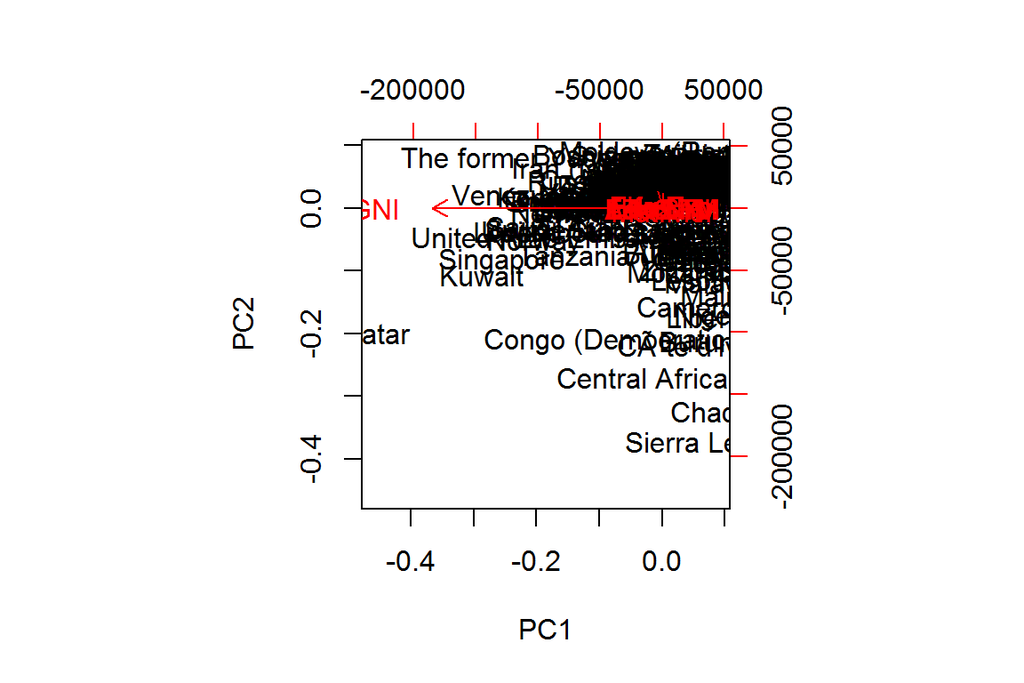

```r
pca_human <- prcomp(human)
biplot(pca_human)
```

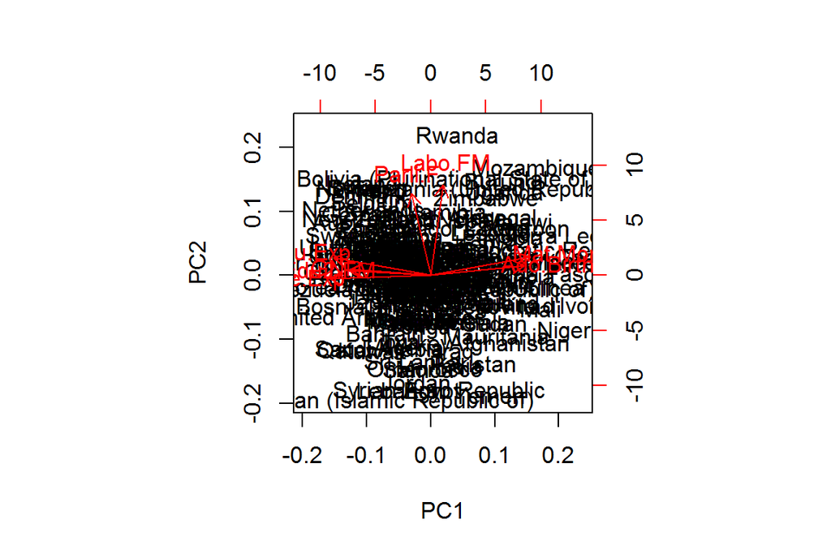

```r
human_std <- scale(human)
pca_human2 <- prcomp(human_std)
biplot(pca_human2)
```

The PCA plots look very different from each other. The plots show where the observations are defined by the 1st and 2nd principal components.The arrows and labels visualize the connections.

In the first biplot, it is visual that the scale of GNI affects the whole plot.GNI has high correlations to PC1.In the scaled data the variance of GNI is scaled down and there for we can see better the rest of the correlations between the variables.

Small angle between the arrows or PC axis means high positive correlation between the two. The length of an arrow is proportional to standard deviation. After scaling the variables are more propotional to each other. We see that most of the variables have high correlations to PC1. Labo.FM and Parli.F has correlation to PC2.

Lets add percentages of the variances to axis labels:

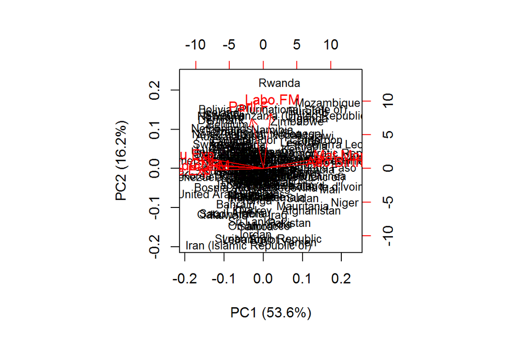

```r
s <- summary(pca_human2)
pca_pr <- round(100*s$importance[2,], digits = 1)
pc_lab <- paste0(names(pca_pr), " (", pca_pr, "%)")
biplot(pca_human2, cex = c(0.8, 1), xlab = pc_lab[1], ylab = pc_lab[2])
```

## The Tea dataset

```r
library(FactoMineR)
library(ggplot2)
library(dplyr)
library(tidyr)
data("tea")
str(tea)
```

```
## 'data.frame':    300 obs. of  36 variables:
##  $ breakfast       : Factor w/ 2 levels "breakfast","Not.breakfast": 1 1 2 2 1 2 1 2 1 1 ...
##  $ tea.time        : Factor w/ 2 levels "Not.tea time",..: 1 1 2 1 1 1 2 2 2 1 ...
##  $ evening         : Factor w/ 2 levels "evening","Not.evening": 2 2 1 2 1 2 2 1 2 1 ...
##  $ lunch           : Factor w/ 2 levels "lunch","Not.lunch": 2 2 2 2 2 2 2 2 2 2 ...
##  $ dinner          : Factor w/ 2 levels "dinner","Not.dinner": 2 2 1 1 2 1 2 2 2 2 ...
##  $ always          : Factor w/ 2 levels "always","Not.always": 2 2 2 2 1 2 2 2 2 2 ...
##  $ home            : Factor w/ 2 levels "home","Not.home": 1 1 1 1 1 1 1 1 1 1 ...
##  $ work            : Factor w/ 2 levels "Not.work","work": 1 1 2 1 1 1 1 1 1 1 ...
##  $ tearoom         : Factor w/ 2 levels "Not.tearoom",..: 1 1 1 1 1 1 1 1 1 2 ...
##  $ friends         : Factor w/ 2 levels "friends","Not.friends": 2 2 1 2 2 2 1 2 2 2 ...
##  $ resto           : Factor w/ 2 levels "Not.resto","resto": 1 1 2 1 1 1 1 1 1 1 ...
##  $ pub             : Factor w/ 2 levels "Not.pub","pub": 1 1 1 1 1 1 1 1 1 1 ...
##  $ Tea             : Factor w/ 3 levels "black","Earl Grey",..: 1 1 2 2 2 2 2 1 2 1 ...
##  $ How             : Factor w/ 4 levels "alone","lemon",..: 1 3 1 1 1 1 1 3 3 1 ...
```

[output cut: 22 more lines]

```r
dim(tea)
```

```
## [1] 300  36
```

The data has 300 observations of 36 variables.Lets analyze and visualize data with smaller set of data:

```r
keep_columns <- c("Tea", "How", "how", "sugar", "where", "lunch")
tea_time <- dplyr::select(tea, one_of(keep_columns))
summary(tea_time)
```

```
##         Tea         How                      how           sugar
##  black    : 74   alone:195   tea bag           :170   No.sugar:155
##  Earl Grey:193   lemon: 33   tea bag+unpackaged: 94   sugar   :145
##  green    : 33   milk : 63   unpackaged        : 36
##                  other:  9
##                   where           lunch
##  chain store         :192   lunch    : 44
##  chain store+tea shop: 78   Not.lunch:256
##  tea shop            : 30
##
```

```r
str(tea_time)
```

```
## 'data.frame':    300 obs. of  6 variables:
##  $ Tea  : Factor w/ 3 levels "black","Earl Grey",..: 1 1 2 2 2 2 2 1 2 1 ...
##  $ How  : Factor w/ 4 levels "alone","lemon",..: 1 3 1 1 1 1 1 3 3 1 ...
##  $ how  : Factor w/ 3 levels "tea bag","tea bag+unpackaged",..: 1 1 1 1 1 1 1 1 2 2 ...
##  $ sugar: Factor w/ 2 levels "No.sugar","sugar": 2 1 1 2 1 1 1 1 1 1 ...
##  $ where: Factor w/ 3 levels "chain store",..: 1 1 1 1 1 1 1 1 2 2 ...
##  $ lunch: Factor w/ 2 levels "lunch","Not.lunch": 2 2 2 2 2 2 2 2 2 2 ...
```

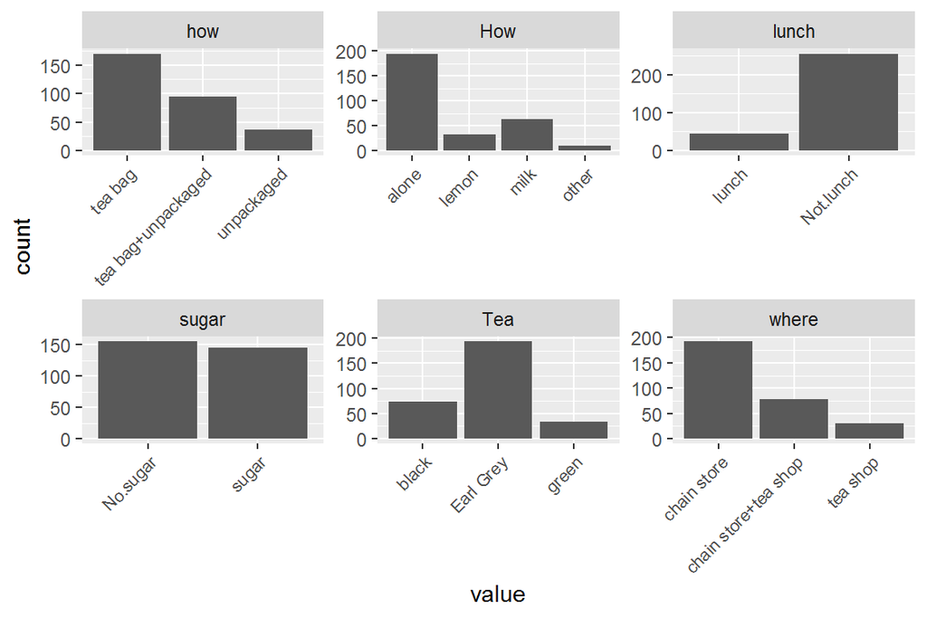

```r
gather(tea_time) %>% ggplot(aes(value)) + facet_wrap("key", scales = "free") + geom_bar() + theme(axis.text.x = element_text(angle = 45, hjust = 1, size = 8))
```

Now there is six variables related to tea drinking habits.Most of the people in this data enjoys their tea out of the lunch hour without any extra.Usually it is chain store Earl Grey.

**MCA analysis**

MCA is dimentionality reduction method for categorical variables just like the tea data.

```r
mca <- MCA(tea_time, graph = FALSE)
summary(mca)
```

```
##
## Call:
## MCA(X = tea_time, graph = FALSE)
##
##
## Eigenvalues
##                        Dim.1   Dim.2   Dim.3   Dim.4   Dim.5   Dim.6
## Variance               0.279   0.261   0.219   0.189   0.177   0.156
## % of var.             15.238  14.232  11.964  10.333   9.667   8.519
## Cumulative % of var.  15.238  29.471  41.435  51.768  61.434  69.953
##                        Dim.7   Dim.8   Dim.9  Dim.10  Dim.11
## Variance               0.144   0.141   0.117   0.087   0.062
## % of var.              7.841   7.705   6.392   4.724   3.385
## Cumulative % of var.  77.794  85.500  91.891  96.615 100.000
##
## Individuals (the 10 first)
##                       Dim.1    ctr   cos2    Dim.2    ctr   cos2    Dim.3
## 1                  | -0.298  0.106  0.086 | -0.328  0.137  0.105 | -0.327
## 2                  | -0.237  0.067  0.036 | -0.136  0.024  0.012 | -0.695
## 3                  | -0.369  0.162  0.231 | -0.300  0.115  0.153 | -0.202
## 4                  | -0.530  0.335  0.460 | -0.318  0.129  0.166 |  0.211
## 5                  | -0.369  0.162  0.231 | -0.300  0.115  0.153 | -0.202
## 6                  | -0.369  0.162  0.231 | -0.300  0.115  0.153 | -0.202
## 7                  | -0.369  0.162  0.231 | -0.300  0.115  0.153 | -0.202
## 8                  | -0.237  0.067  0.036 | -0.136  0.024  0.012 | -0.695
## 9                  |  0.143  0.024  0.012 |  0.871  0.969  0.435 | -0.067
## 10                 |  0.476  0.271  0.140 |  0.687  0.604  0.291 | -0.650
##                       ctr   cos2
## 1                   0.163  0.104 |
## 2                   0.735  0.314 |
## 3                   0.062  0.069 |
## 4                   0.068  0.073 |
## 5                   0.062  0.069 |
## 6                   0.062  0.069 |
## 7                   0.062  0.069 |
## 8                   0.735  0.314 |
## 9                   0.007  0.003 |
## 10                  0.643  0.261 |
##
## Categories (the 10 first)
```

[output cut: 16 more lines]

```
## lemon                0.035   3.226 |   1.329  14.771   0.218   8.081 |
## milk                 0.020   2.422 |   0.013   0.003   0.000   0.116 |
## other                0.102   5.534 |  -2.524  14.526   0.197  -7.676 |
## tea bag              0.161  -6.941 |  -0.065   0.183   0.006  -1.287 |
## tea bag+unpackaged   0.478  11.956 |   0.019   0.009   0.000   0.226 |
## unpackaged           0.141  -6.482 |   0.257   0.602   0.009   1.640 |
##
## Categorical variables (eta2)
##                      Dim.1 Dim.2 Dim.3
## Tea                | 0.126 0.108 0.410 |
## How                | 0.076 0.190 0.394 |
## how                | 0.708 0.522 0.010 |
## sugar              | 0.065 0.001 0.336 |
## where              | 0.702 0.681 0.055 |
## lunch              | 0.000 0.064 0.111 |
```

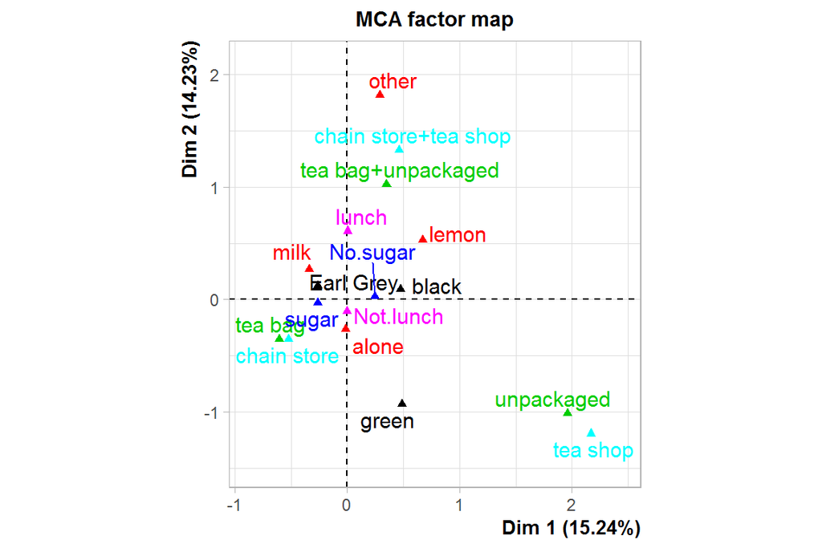

```r
plot(mca, invisible=c("ind"), habillage = "quali")
```